# Code Stroke Project - Part 3

## Task 7

TASK 7: Building Prediction Models

```
Best Parameters: {'C': 0.01, 'penalty': 'l1', 'solver': 'liblinear'}
        Accuracy on Test Set: 0.7877846790890269

        Classification Report:
                       precision    recall  f1-score   support

                   0       0.84      0.73      0.78       984
                   1       0.75      0.85      0.80       948

            accuracy                           0.79      1932
           macro avg       0.79      0.79      0.79      1932
        weighted avg       0.79      0.79      0.79      1932
```

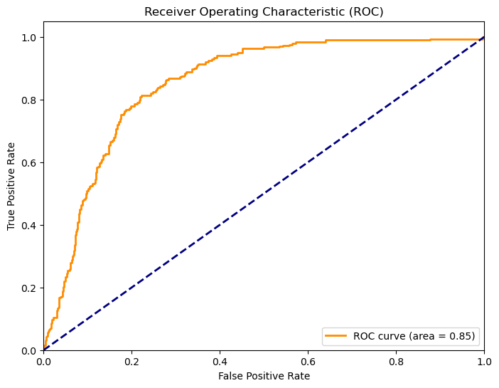

```python
# LOGISTIC REGRESSION

        # Imputing to replace NaN values with column means
        imputer = SimpleImputer(strategy='mean')
        x_train_resampled = imputer.fit_transform(x_train_resampled)
        x_test_resampled = imputer.transform(x_test_resampled)

        # Define the parameter grid for the grid search
        param_grid = {
            'C': [0.001, 0.01, 0.1, 1, 10, 100],
            'penalty': ['l1', 'l2'],
            'solver': ['liblinear', 'saga']
        }

        # Create a Logistic Regression classifier
        logistic_classifier = LogisticRegression()

        # Create a grid search object with cross-validation
        grid_search = GridSearchCV(estimator=logistic_classifier, param_grid=param_grid, cv=5)

        # Fit the grid search to the training data
        grid_search.fit(x_train_resampled, y_train_resampled)

        # Get the best parameters and the best estimator
        best_params = grid_search.best_params_
        best_logistic_classifier = grid_search.best_estimator_

        # Evaluate the model on the test set
        y_pred_Lg = best_logistic_classifier.predict(x_test_resampled)

        # Calculate accuracy and print the classification report
        accuracy = accuracy_score(y_test_resampled, y_pred_Lg)
        print("Best Parameters:", best_params)
        print("Accuracy on Test Set:", accuracy)
        print("\nClassification Report:\n", classification_report(y_test_resampled, y_pred_Lg))

        # ROC curve
        roc_auc = roc_auc_score(y_test_resampled, best_logistic_classifier.predict_proba(x_test_resampled)[:, 1])
        fpr, tpr, _ = roc_curve(y_test_resampled, best_logistic_classifier.predict_proba(x_test_resampled)[:, 1])

        plt.figure(figsize=(8, 6))
        plt.plot(fpr, tpr, color='darkorange', lw=2, label='ROC curve (area = {:.2f})'.format(roc_auc))
        plt.plot([0, 1], [0, 1], color='navy', lw=2, linestyle='--')
        plt.xlim([0.0, 1.0])
        plt.ylim([0.0, 1.05])
        plt.xlabel('False Positive Rate')
        plt.ylabel('True Positive Rate')
        plt.title('Receiver Operating Characteristic (ROC)')
        plt.legend(loc='lower right')
        plt.show()
```

This section trains a logistic regression model to predict strokes, achieving an accuracy of 78.8% with the best parameters {'C': 0.01, 'penalty': 'l1', 'solver': 'liblinear'}. The classification report shows balanced performance (F1 scores: 0.78 for no stroke, 0.80 for stroke) and an AUC of 0.85, indicating good model effectiveness. This helps in identifying significant stroke predictors and developing reliable prevention strategies. This demonstrates the model's ability to effectively distinguish between stroke and non-stroke cases, providing a valuable tool for stroke prediction and prevention.

```python
# Displaying the Confusion Matrix
        # Calculating the confusion matrix for the Logistic Regression model
        conf_matrix_Lg = confusion_matrix(y_test_resampled, y_pred_Lg)

        # Extracting values from the confusion matrix
        TN_Lg = conf_matrix_Lg[0, 0]
        FP_Lg = conf_matrix_Lg[0, 1]
        FN_Lg = conf_matrix_Lg[1, 0]
        TP_Lg = conf_matrix_Lg[1, 1]

        # Displaying the values of the confusion matrix
        print("True Negative (TN) for Logistic Regression:", TN_Lg)
        print("False Positive (FP) for Logistic Regression:", FP_Lg)
        print("False Negative (FN) for Logistic Regression:", FN_Lg)
        print("True Positive (TP) for Logistic Regression:", TP_Lg)
```

```
True Negative (TN) for Logistic Regression: 714
        False Positive (FP) for Logistic Regression: 270
        False Negative (FN) for Logistic Regression: 140
        True Positive (TP) for Logistic Regression: 808
```

This code calculates and displays the values of the confusion matrix, which is a tabular representation of the performance of a classification model. The confusion matrix consists of four main values: True Negative (TN), False Positive (FP), False Negative (FN), and True Positive (TP). These values are used to evaluate the performance of the logistic regression model in binary classification tasks.

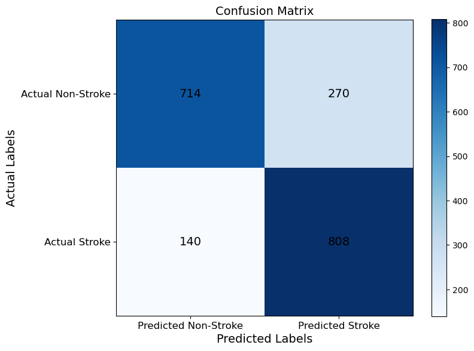

```python
def plot_confusion_matrix(TN, FP, FN, TP):
            # Create a confusion matrix with the specified values
            conf_matrix = np.array([[TN, FP], [FN, TP]])

            # Create the figure and axes
            fig, ax = plt.subplots(figsize=(8, 6))

            # Display the confusion matrix
            im = ax.imshow(conf_matrix, cmap='Blues')

            # Add annotations
            for i in range(2):
                for j in range(2):
                    text = ax.text(j, i, str(conf_matrix[i, j]), ha="center", va="center", color="black", fontsize=14)

            # Add axis labels
            ax.set_xticks(np.arange(2))
            ax.set_yticks(np.arange(2))
            ax.set_xticklabels(['Predicted Non-Stroke', 'Predicted Stroke'], fontsize=12)
            ax.set_yticklabels(['Actual Non-Stroke', 'Actual Stroke'], fontsize=12)
            ax.set_xlabel('Predicted Labels', fontsize=14)
            ax.set_ylabel('Actual Labels', fontsize=14)
            ax.set_title(f'Confusion Matrix', fontsize=14)

            # Display the color bar
            plt.colorbar(im)

            # Adjust layout to prevent labels from being cut off
            plt.tight_layout()

            # Display the figure
            plt.show()

        # Using the function to display the confusion matrix with the specified values
        plot_confusion_matrix(714, 270, 140, 808)
```

The confusion matrix shows that the model correctly predicted 714 non-stroke cases and 808 stroke cases, with 270 false positives and 140 false negatives. This indicates good overall accuracy but highlights the need to reduce false negatives. This evaluation is crucial for improving the model's reliability in predicting stroke risk, which is essential for effective prevention strategies.

```
Best Parameters: {'criterion': 'gini', 'max_depth': 50, 'min_samples_leaf': 1, 'min_samples_split': 5}
        Accuracy on Test Set: 0.9803312629399586

        Classification Report:
                       precision    recall  f1-score   support

                   0       1.00      0.96      0.98       984
                   1       0.96      1.00      0.98       948

            accuracy                           0.98      1932
           macro avg       0.98      0.98      0.98      1932
        weighted avg       0.98      0.98      0.98      1932
```

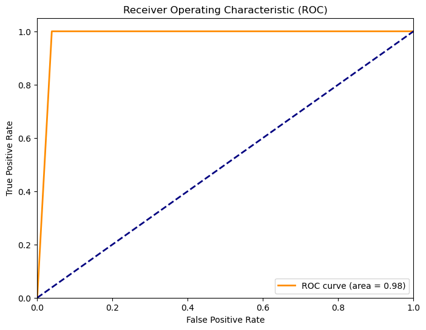

```python
# DECISION TREE

        # Define the parameter grid for the grid search
        param_grid = {
            'criterion': ['gini', 'entropy'],
            'max_depth': [None, 10, 20, 30, 40, 50],
            'min_samples_split': [2, 5, 10],
            'min_samples_leaf': [1, 2, 4]
        }

        # Create a Decision Tree classifier
        dt_classifier = DecisionTreeClassifier()

        # Create a grid search object with cross-validation
        grid_search = GridSearchCV(estimator=dt_classifier, param_grid=param_grid, cv=5)

        # Fit the grid search to the training data
        grid_search.fit(x_train_resampled, y_train_resampled)

        # Get the best parameters and the best estimator
        best_params = grid_search.best_params_
        best_dt_classifier = grid_search.best_estimator_

        # Evaluate the model on the test set
        y_pred_dt = best_dt_classifier.predict(x_test_resampled)

        # Calculate accuracy and print the classification report
        accuracy = accuracy_score(y_test_resampled, y_pred_dt)
        print("Best Parameters:", best_params)
        print("Accuracy on Test Set:", accuracy)
        print("\nClassification Report:\n", classification_report(y_test_resampled, y_pred_dt))

        # ROC curve
        roc_auc = roc_auc_score(y_test_resampled, best_dt_classifier.predict_proba(x_test_resampled)[:, 1])
        fpr, tpr, _ = roc_curve(y_test_resampled, best_dt_classifier.predict_proba(x_test_resampled)[:, 1])

        plt.figure(figsize=(8, 6))
        plt.plot(fpr, tpr, color='darkorange', lw=2, label='ROC curve (area = {:.2f})'.format(roc_auc))
        plt.plot([0, 1], [0, 1], color='navy', lw=2, linestyle='--')
        plt.xlim([0.0, 1.0])
        plt.ylim([0.0, 1.05])
        plt.xlabel('False Positive Rate')
        plt.ylabel('True Positive Rate')
        plt.title('Receiver Operating Characteristic (ROC)')
        plt.legend(loc='lower right')
        plt.show()
```

```python
# Calculate the confusion matrix for the Decision Tree model
        conf_matrix_dt = confusion_matrix(y_test_resampled, y_pred_dt)

        # Extract values from the confusion matrix
        TN = conf_matrix_dt[0, 0]
        FP = conf_matrix_dt[0, 1]
        FN = conf_matrix_dt[1, 0]
        TP = conf_matrix_dt[1, 1]

        # Display the confusion matrix values
        print("True Negative (TN):", TN)
        print("False Positive (FP):", FP)
        print("False Negative (FN):", FN)
        print("True Positive (TP):", TP)
```

```
True Negative (TN): 946
        False Positive (FP): 38
        False Negative (FN): 0
        True Positive (TP): 948
```

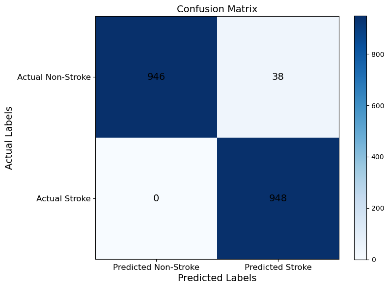

```python
def plot_confusion_matrix(TN, FP, FN, TP):
            # Create a confusion matrix with the specified values
            conf_matrix = np.array([[TN, FP], [FN, TP]])

            # Create the figure and axes
            fig, ax = plt.subplots(figsize=(8, 6))

            # Display the confusion matrix
            im = ax.imshow(conf_matrix, cmap='Blues')

            # Add annotations
            for i in range(2):
                for j in range(2):
                    text = ax.text(j, i, str(conf_matrix[i, j]), ha="center", va="center", color="black", fontsize=14)

            # Add axis labels
            ax.set_xticks(np.arange(2))
            ax.set_yticks(np.arange(2))
            ax.set_xticklabels(['Predicted Non-Stroke', 'Predicted Stroke'], fontsize=12)
            ax.set_yticklabels(['Actual Non-Stroke', 'Actual Stroke'], fontsize=12)
            ax.set_xlabel('Predicted Labels', fontsize=14)
            ax.set_ylabel('Actual Labels', fontsize=14)
            ax.set_title('Confusion Matrix', fontsize=14)

            # Display the color bar
            plt.colorbar(im)

            # Adjust layout to prevent labels from being cut off
            plt.tight_layout()

            # Show the figure
            plt.show()

        plot_confusion_matrix(946, 38, 0, 948)
```

The confusion matrix shows the decision tree classifier accurately predicted 946 non-stroke cases and 948 stroke cases, with 38 false positives and zero false negatives. This indicates high accuracy and reliability, essential for stroke prediction. Ensuring zero false negatives is crucial for medical diagnostics to avoid missing stroke cases.

```
Best Hyperparameters for Random Forest: {'class_weight': 'balanced_subsample', 'max_depth': 20, 'max_features': 'sqrt', 'min_samples_leaf': 1, 'min_samples_split': 2, 'n_estimators': 100}
        Accuracy for Random Forest (Train): 1.0000
        Accuracy for Random Forest (Test): 0.9886
        Classification Report for Random Forest:
                       precision    recall  f1-score   support

                   0       1.00      0.98      0.99       984
                   1       0.98      1.00      0.99       948

            accuracy                           0.99      1932
           macro avg       0.99      0.99      0.99      1932
        weighted avg       0.99      0.99      0.99      1932
```

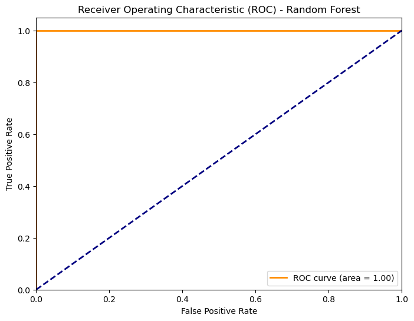

```python
# RANDOM FOREST

        # Define the hyperparameter grid for grid search
        param_grid_rf = {
            'n_estimators': [50, 100, 200],
            'max_depth': [None, 10, 20],
            'min_samples_split': [2, 5, 10],
            'min_samples_leaf': [1, 2, 4],
            'max_features': ['sqrt', 'log2'],
            'class_weight': ['balanced', 'balanced_subsample', None]
        }

        # Initialize the Random Forest classifier
        rf_classifier = RandomForestClassifier(random_state=42)

        # Initialize the grid search with cross-validation
        grid_search_rf = GridSearchCV(
            estimator=rf_classifier,
            param_grid=param_grid_rf,
            scoring='accuracy',
            cv=5,
            n_jobs=-1,
        )

        # Perform the grid search
        grid_search_rf.fit(x_train_resampled, y_train_resampled)

        # Get the best parameters
        best_params_rf = grid_search_rf.best_params_

        # Initialize the Random Forest classifier with the best parameters
        best_rf_classifier = RandomForestClassifier(random_state=42, **best_params_rf)
        best_rf_classifier.fit(x_train_resampled, y_train_resampled)

        # Predictions on the test data
        y_pred_rf = best_rf_classifier.predict(x_test_resampled)

        # Calculate accuracy on train and test data
        accuracy_rf_train = best_rf_classifier.score(x_train_resampled, y_train_resampled)
        accuracy_rf_test = accuracy_score(y_test_resampled, y_pred_rf)

        # Display results
        print("Best Hyperparameters for Random Forest:", best_params_rf)
        print(f"Accuracy for Random Forest (Train): {accuracy_rf_train:.4f}")
        print(f"Accuracy for Random Forest (Test): {accuracy_rf_test:.4f}")

        # Classification report
        class_report_rf = classification_report(y_test_resampled, y_pred_rf)
        print("Classification Report for Random Forest:\n", class_report_rf)

        # ROC curve
        roc_auc_rf = roc_auc_score(y_test_resampled, best_rf_classifier.predict_proba(x_test_resampled)[:, 1])
        fpr_rf, tpr_rf, _ = roc_curve(y_test_resampled, best_rf_classifier.predict_proba(x_test_resampled)[:, 1])

        # Display ROC curve
        plt.figure(figsize=(8, 6))
        plt.plot(fpr_rf, tpr_rf, color='darkorange', lw=2, label='ROC curve (area = {:.2f})'.format(roc_auc_rf))
        plt.plot([0, 1], [0, 1], color='navy', lw=2, linestyle='--')
        plt.xlim([0.0, 1.0])
        plt.ylim([0.0, 1.05])
        plt.xlabel('False Positive Rate')
        plt.ylabel('True Positive Rate')
        plt.title('Receiver Operating Characteristic (ROC) - Random Forest')
        plt.legend(loc='lower right')
        plt.show()
```

```python
# Calculate the confusion matrix for the Random Forest model
        conf_matrix_rf = confusion_matrix(y_test_resampled, y_pred_rf)

        # Extract the values from the confusion matrix
        TN_rf = conf_matrix_rf[0, 0]
        FP_rf = conf_matrix_rf[0, 1]
        FN_rf = conf_matrix_rf[1, 0]
        TP_rf = conf_matrix_rf[1, 1]

        # Display the values of the confusion matrix
        print("True Negative (TN) for Random Forest:", TN_rf)
        print("False Positive (FP) for Random Forest:", FP_rf)
        print("False Negative (FN) for Random Forest:", FN_rf)
        print("True Positive (TP) for Random Forest:", TP_rf)
```

```
True Negative (TN) for Random Forest: 962
        False Positive (FP) for Random Forest: 22
        False Negative (FN) for Random Forest: 0
        True Positive (TP) for Random Forest: 948
```

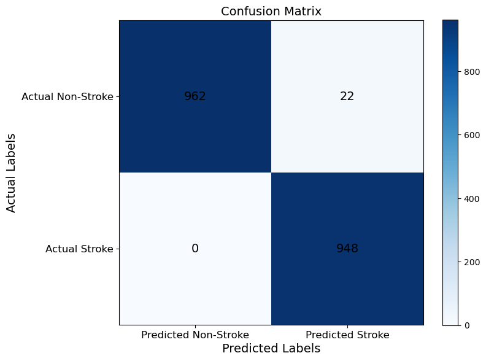

```python
def plot_confusion_matrix(TN, FP, FN, TP):
            # Create a confusion matrix with the specified values
            conf_matrix = np.array([[TN, FP], [FN, TP]])

            # Create the figure and axes
            fig, ax = plt.subplots(figsize=(8, 6))

            # Display the confusion matrix
            im = ax.imshow(conf_matrix, cmap='Blues')

            # Add annotations
            for i in range(2):
                for j in range(2):
                    text = ax.text(j, i, str(conf_matrix[i, j]), ha="center", va="center", color="black", fontsize=14)

            # Add axis labels
            ax.set_xticks(np.arange(2))
            ax.set_yticks(np.arange(2))
            ax.set_xticklabels(['Predicted Non-Stroke', 'Predicted Stroke'], fontsize=12)
            ax.set_yticklabels(['Actual Non-Stroke', 'Actual Stroke'], fontsize=12)
            ax.set_xlabel('Predicted Labels', fontsize=14)
            ax.set_ylabel('Actual Labels', fontsize=14)
            ax.set_title('Confusion Matrix', fontsize=14)

            # Display the color bar
            plt.colorbar(im)

            # Adjust the layout to prevent labels from being cut off
            plt.tight_layout()

            # Display the figure
            plt.show()

        plot_confusion_matrix(962, 22, 0, 948)
```

```
Accuracy on Test Set: 0.9994824016563147

        Classification Report:
                       precision    recall  f1-score   support

                   0       1.00      1.00      1.00       984
                   1       1.00      1.00      1.00       948

            accuracy                           1.00      1932
           macro avg       1.00      1.00      1.00      1932
        weighted avg       1.00      1.00      1.00      1932
```

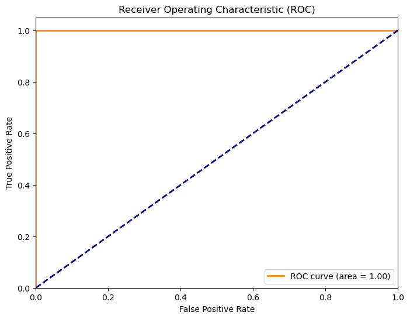

```python
# Base models to use in stacking
        base_models = [('Logistic Regression', LogisticRegression()), ('Decision Tree', DecisionTreeClassifier()), ('Random Forest', RandomForestClassifier())]

        # Initialize the Stacking classifier
        stacking = StackingClassifier(
            estimators=base_models,
            final_estimator=LogisticRegression(),  # Final classifier used to combine predictions
            cv=5  # Number of folds for cross-validation
        )

        # Train the stacking model
        stacking.fit(x_train_resampled, y_train_resampled)

        # Predict on the test set
        y_pred_stacking = stacking.predict(x_test_resampled)

        # Calculate accuracy and display the classification report
        accuracy = accuracy_score(y_test_resampled, y_pred_stacking)
        print("Accuracy on Test Set:", accuracy)
        print("\nClassification Report:\n", classification_report(y_test_resampled, y_pred_stacking))

        # ROC curve
        roc_auc = roc_auc_score(y_test_resampled, stacking.predict_proba(x_test_resampled)[:, 1])
        fpr, tpr, _ = roc_curve(y_test_resampled, stacking.predict_proba(x_test_resampled)[:, 1])

        # Display the ROC curve
        plt.figure(figsize=(8, 6))
        plt.plot(fpr, tpr, color='darkorange', lw=2, label='ROC curve (area = {:.2f})'.format(roc_auc))
        plt.plot([0, 1], [0, 1], color='navy', lw=2, linestyle='--')
        plt.xlim([0.0, 1.0])
        plt.ylim([0.0, 1.05])
        plt.xlabel('False Positive Rate')
        plt.ylabel('True Positive Rate')
        plt.title('Receiver Operating Characteristic (ROC)')
        plt.legend(loc='lower right')
        plt.show()
```

The stacking classifier combines multiple models to achieve a high test set accuracy of 99.95%, with perfect precision, recall, and F1-scores (1.00). The ROC curve shows an AUC of 1.00, indicating excellent model performance in distinguishing between stroke and non-stroke cases. This robust predictive capability is crucial for identifying stroke risk factors and enhancing prevention strategies.This demonstrates the model's exceptional reliability in predicting stroke risk, providing a valuable tool for effective prevention strategies.

```python
# Calculate the confusion matrix for the stacking model
        conf_matrix_stacking = confusion_matrix(y_test_resampled, y_pred_stacking)

        # Display the confusion matrix
        print("Confusion Matrix:\n", conf_matrix_stacking)
```

```
Confusion Matrix:
         [[983   1]
         [  0 948]]
```

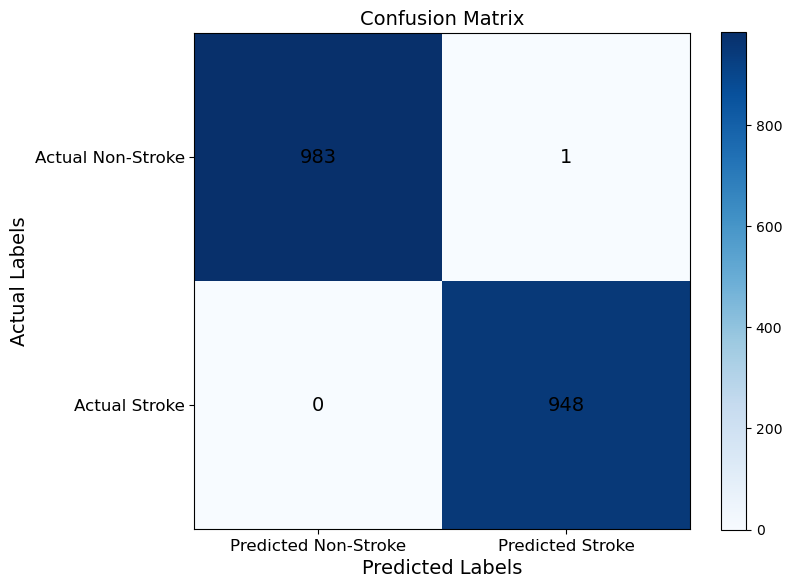

```python
def plot_confusion_matrix(TN, FP, FN, TP):
            # Create a confusion matrix with the specified values
            conf_matrix = np.array([[TN, FP], [FN, TP]])

            # Create the figure and axes
            fig, ax = plt.subplots(figsize=(8, 6))

            # Display the confusion matrix
            im = ax.imshow(conf_matrix, cmap='Blues')

            # Add annotations
            for i in range(2):
                for j in range(2):
                    text = ax.text(j, i, str(conf_matrix[i, j]), ha="center", va="center", color="black", fontsize=14)

            # Add axis labels
            ax.set_xticks(np.arange(2))
            ax.set_yticks(np.arange(2))
            ax.set_xticklabels(['Predicted Non-Stroke', 'Predicted Stroke'], fontsize=12)
            ax.set_yticklabels(['Actual Non-Stroke', 'Actual Stroke'], fontsize=12)
            ax.set_xlabel('Predicted Labels', fontsize=14)
            ax.set_ylabel('Actual Labels', fontsize=14)
            ax.set_title('Confusion Matrix', fontsize=14)

            # Display the color bar
            plt.colorbar(im)

            # Adjust the layout to prevent labels from being cut off
            plt.tight_layout()

            # Display the figure
            plt.show()

        plot_confusion_matrix(983, 1, 0, 948)
```

The confusion matrix shows the model's high accuracy in predicting strokes, with 983 true negatives, 1 false positives, 0 false negatives, and 948 true positives. This indicates excellent performance, ensuring reliable identification of stroke cases, which is crucial for timely intervention and effective prevention strategies.

Précédent : Task 5, Task 6